# Final Project

**Full Error Metrics by Iteration**

```r
zillow_cv_forecast %>%
  group_by(.id) %>%
  accuracy(df_tsbl) %>%
  ungroup() %>%
  data.table()
```

```
           .model   .id  .type          ME      RMSE        MAE         MPE
           <char> <int> <char>       <num>     <num>      <num>       <num>
 1:    best_arima     1   Test         NaN       NaN        NaN         NaN
 2:    best_arima     2   Test   43.625728  139.0823  122.17388   1.0306023
 3:    best_arima     3   Test  232.118528  276.1878  232.11853   7.7373765
 4:    best_arima     4   Test  168.706494  211.3730  173.52261   5.4362116
 5:    best_arima     5   Test   13.007946  234.9394  191.22071   0.3669199
 6:    best_arima     6   Test   13.283029  118.1845   93.33431   0.3230207
 7:    best_arima     7   Test -158.681982  301.6630  214.11212  -4.4108669
 8:    best_arima     8   Test -549.897763  722.2415  558.87587 -20.3123045
 9: naive_w_drift     1   Test  894.466102 1050.0230  895.18362  30.6020930
10: naive_w_drift     2   Test  761.490610  903.1348  768.98357  26.8996303
11: naive_w_drift     3   Test 1059.287149 1219.4064 1059.28715  34.8003576
12: naive_w_drift     4   Test 1069.564912 1217.1518 1069.56491  32.4861307
13: naive_w_drift     5   Test 1095.566978 1238.9213 1095.56698  31.5704763
```

[output cut: 39 more lines]

**Average Accuracy Comparison**

```r
zillow_cv_forecast %>%
  accuracy(df_tsbl) %>%
  data.table()
```

```
          .model  .type         ME      RMSE       MAE       MPE      MAPE
          <char> <char>      <num>     <num>     <num>     <num>     <num>
1:    best_arima   Test  -33.97686  342.6993  226.4797 -1.404149  7.709616
2: naive_w_drift   Test 1030.55462 1194.5733 1031.5809 31.992483 32.050915
3: prophet_model   Test  -68.53893  365.6783  310.6335 -3.775146 11.722986
        MASE    RMSSE      ACF1
       <num>    <num>     <num>
1: 0.8550071 1.033318 0.6066927
2: 3.8944282 3.601917 0.3036937
3: 1.1727049 1.102605 0.4565864
```

Lower values of RMSE (Root Mean Squared Error) and MASE (Mean Absolute Scaled Error) indicate better performance of the model. Upon comparing these metrics, it becomes evident that the ARIMA model outperforms the other models.

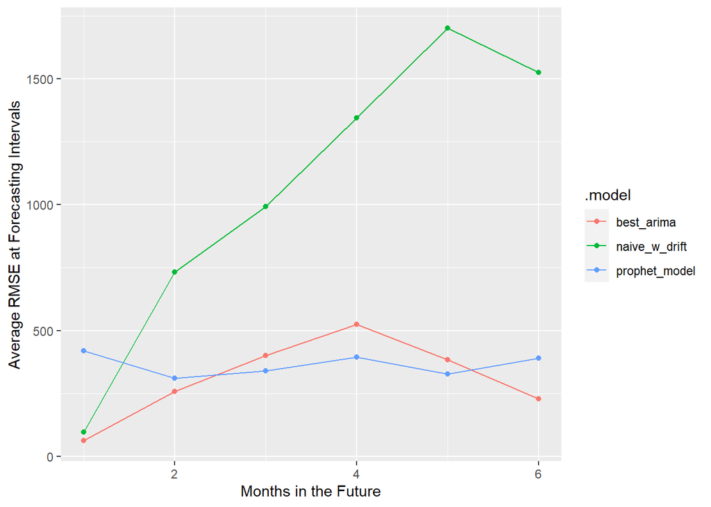

```r
zillow_cv_forecast %>%
  group_by(.id,.model) %>%
  mutate(h = row_number()) %>%
  ungroup() %>%
  as_fable(response = "zillow_sales", distribution = zillow_sales) %>%
  accuracy(df_tsbl, by = c("h", ".model")) %>%
  ggplot(aes(x = h, y = RMSE,color=.model)) +
  geom_point()+
  geom_line()+
  ylab('Average RMSE at Forecasting Intervals')+
  xlab('Months in the Future')
```

The graph also indicates that ARIMA model is better.

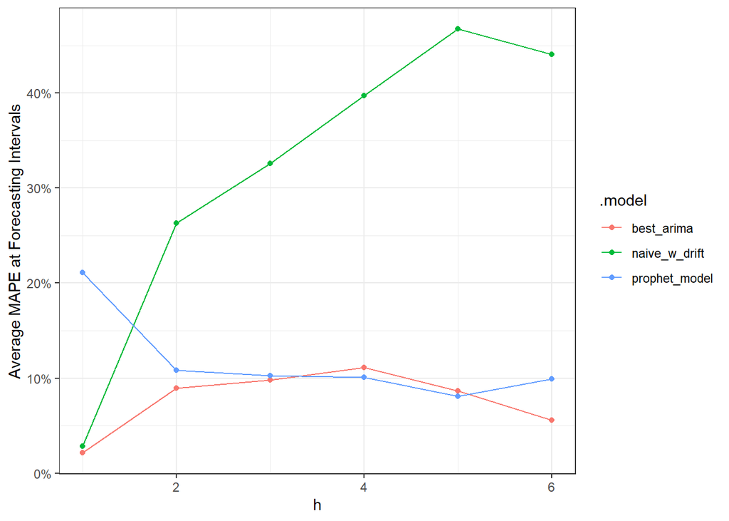

```r
zillow_cv_forecast %>%
  group_by(.id,.model) %>%
  mutate(h = row_number()) %>%
  ungroup() %>%
  as_fable(response = "zillow_sales", distribution = zillow_sales) %>%
  accuracy(df_tsbl, by = c("h", ".model")) %>%
  mutate(MAPE = MAPE/100) %>% # Rescale
  ggplot(aes(x = h, y = MAPE,color=.model)) +
  geom_point()+
  geom_line()+
  theme_bw()+
  scale_y_continuous(
    name = 'Average MAPE at Forecasting Intervals',labels=scales::percent)
```

Upon analyzing the RMSE and MAPE plots provided above, it can be concluded that the ARIMA forecast model demonstrates superior performance compared to the Prophet model for our time series forecasting task. This observation is consistent with our initial expectations.

## Final Test Set Forecast

```r
zillow_train_mod <- zillow_train %>%
  model(
    prophet(zillow_sales)
  )
```

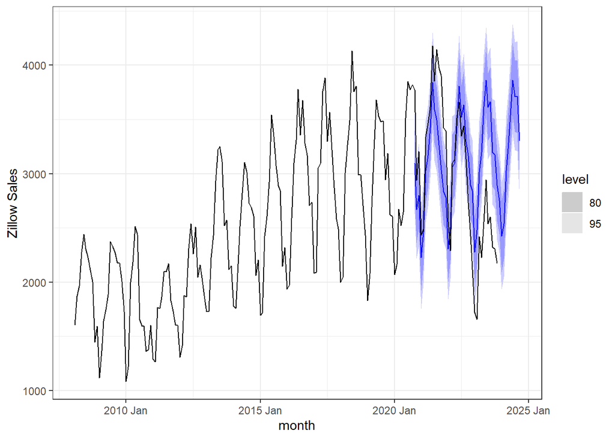

```r
zillow_train_mod %>%
    forecast(h=48) %>%
    autoplot(zillow_train %>%
    bind_rows(zillow_test))+
    ylab('Zillow Sales')+
    theme_bw()
```

```r
zillow_train_mod %>%
    forecast(h=48) %>%
    accuracy(zillow_test)
```

```
# A tibble: 1 × 10
  .model                .type    ME  RMSE   MAE   MPE  MAPE  MASE RMSSE  ACF1
  <chr>                 <chr> <dbl> <dbl> <dbl> <dbl> <dbl> <dbl> <dbl> <dbl>
1 prophet(zillow_sales) Test  -138.  592.  496. -8.46  18.6   NaN   NaN 0.894
```

```r
zillow_full_model <- df_tsbl %>%
  model(
    arima = ARIMA(zillow_sales)
  )
```

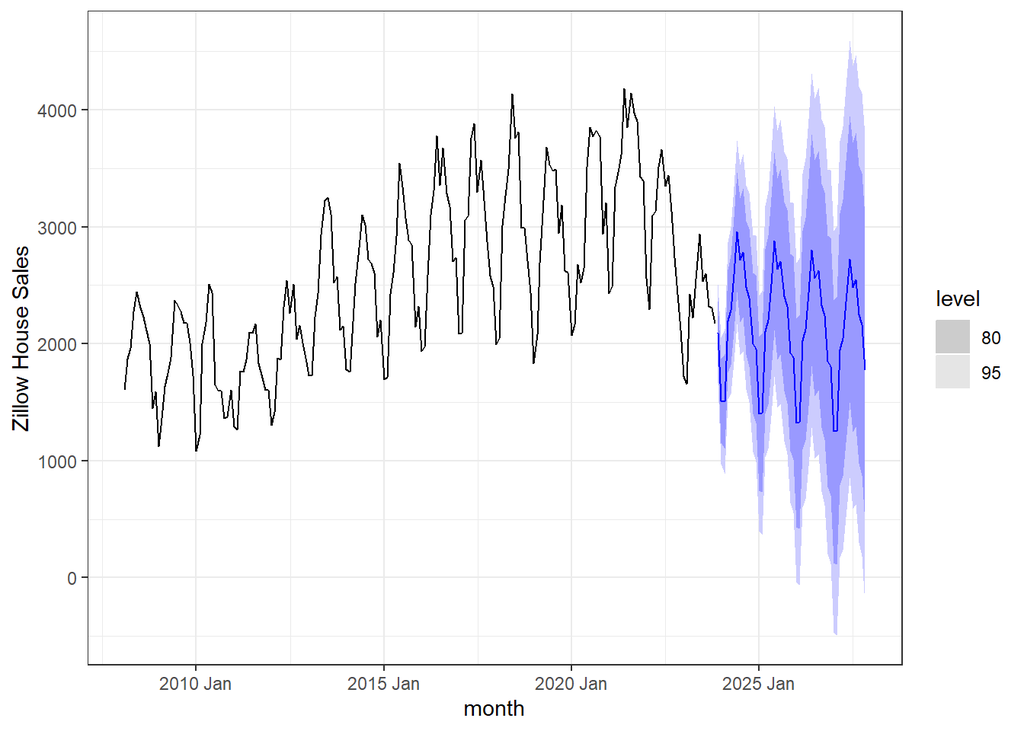

```r
zillow_full_model %>%
    forecast(h=48) %>%
    autoplot(df_tsbl) %>%+
    ylab('Zillow House Sales')+
    theme_bw()
```

The forecasted values demonstrate a strong alignment with the observed trend in the time series data, indicating that the forecasting model adequately captures the underlying patterns and variations in the dataset.